# Python básico - Caderno 01

# Tipos e objetos

Este caderno busca conter a primeira parte sobre Python básico e inclui:

- Por que Python?
- Instalação e configurações
- Variáveis
- Input de usuário
- Listas e tuplas
- Dicionários

## Por que Python?

Python é uma linguagem interpretada de alto nível amplamente utilizada nas mais diversas áreas devido a sua capacidade de satisfazer as necessidades dos iniciantes até os mais experientes, por ser uma linguagem multiparadigma, ela suporta tanto códigos voltados a orientação a objetos quanto escritos de forma estrutural ou em forma de script. Sua sintaxe é simples e limpa, ótima para um desenvolvimento rápido, testes e manutenção. Sua ampla comunidade nos fornece uma incrível gama de bibliotecas e frameworks que cobrem desde desenvolvimento web até tópicos como aprendizado de máquina e estatística. Sua popularidade vem crescendo gradualmente, para demonstrar isto, mostraremos uma pesquisa anual realizada pela equipe do mais famoso fórum de linguagens de programação, o [stackoverflow](https://stackoverflow.com). Veja os resultados da pesquisa referente a 2019 abaixo:

#### Entre as mais amadas

Python aparece em segundo lugar entre as linguagens mais amadas deste ano, perdendo apenas para Rust.

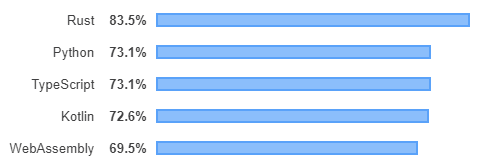

[figure not shown]

Para saber mais a respeito desta pesquisa acesse o seguinte [link](https://insights.stackoverflow.com/survey/2019).

Em resumo estas são as características que fazem a linguagem estar em grande destaque.

- Linguagem de uso geral
- Escalabilidade
- Simplicidade dos códigos
- Usabilidade
- Velocidade de aplicação
- Vasta comunidade diposta a ajudar
- Incrível gama de bibliotecas
- Multiparadigma

## Instalação e configurações

### Windows

Acesse o site https://www.python.org/downloads/ e siga as instruções do próprio instalador.

[figure not shown]

### Linux

Em distribuições Linux o python geralmente já vem instalado na versão 2.7.

Abra o terminal (CTRL + ALT + T) e use o seguinte comando para checar a versão e se realmente foi instalado.

```
$ python --version
```

Estaremos usando a versão 3.x do Python nesta oficina, verifique se já se encontra instalado usando

```
$ python3 --version
```

Caso algum erro aconteça devemos instalar a versão mais recente do Python, para isto, ainda no terminal digite.

```
$ sudo apt-get update
```

Logo após isto, execute o seguinte comando.

```
$ sudo apt-get install python3
```

### Outras formas de instalação

O Anaconda é uma plataforma que gerencia pacotes e IDEs, como Jupyter Notebook, Spyder e VS Code, sendo ideal para data science.

Acesse o site https://www.anaconda.com/distribution/ e escolha o seu sistema operacional e a versão desejada do Python para instalação.

[figure not shown]

## Variáveis

### Tipos de Variáveis

Como toda linguagem de programação, o Python possui uma série de tipos de variáveis. Aqui estudaremos as mais comuns e utilizaremos alguns métodos pertencentes a estes tipos.

**String**  
Strings são cadeias de caracteres usadas para representar palavras ou elementos textuais em um programa.

```python
saudacao = 'Olá'
type(saudacao)
```

```
str
```

**Integer**  
São variáveis que guardam números inteiros.

```python
numero_favorito = 7
type(numero_favorito)
```

```
int
```

**Float**  
São os pontos flutuantes ou números reais.

```python
altura = 1.70
type(altura)
```

```
float
```

**Boolean**  
Booleanos são variáveis que possuem os valores `True` ou `False`, são geralmente utilizadas para controle de fluxo.

```python
sabe_nadar = False
type(sabe_nadar)
```

```
bool
```

### Strings

Formatando a string

```python
meu_nome = 'dAnIel'
print(meu_nome.title())
print(meu_nome.lower())
print(meu_nome.upper())
```

```
Daniel
daniel
DANIEL
```

Removendo espaços em branco.

```python
meu_nome = '     \n\n dAnIel \t\t\n   '
print(meu_nome)
```

```
 dAnIel
```

O método `rstrip` remove os espaços em branco à direita da string.

```python
print(meu_nome.rstrip())
```

```
 dAnIel
```

Análogo ao método `rstrip` o método `lstrip` remove os espaços em braco à esquerda da string.

```python
print(meu_nome.lstrip())
```

```
dAnIel
```

`strip` remove espaços de amobos os lados.

```python
print(meu_nome.strip())
```

```
dAnIel
```

Veja que `meu_nome` não foi modificado.

```python
print(meu_nome)
```

```
 dAnIel
```

```python
meu_nome = '      dAnIel    '
print(meu_nome.strip().title())
```

```
Daniel
```

#### Concatenando Strings

```python
pagodeiro_um = 'Péricles'
pagodeiro_dois = 'Mumuzinho'
pagodeiro_tres = 'Thiaguinho'

mensagem = 'canta pagode.'

print(pagodeiro_um + ' ' + mensagem)
print(pagodeiro_dois + ' ' + mensagem)
print(pagodeiro_tres + ' ' + mensagem)
```

```
Péricles canta pagode.
Mumuzinho canta pagode.
Thiaguinho canta pagode.
```

```python
print(pagodeiro_um + ' e ' + pagodeiro_tres + ' já foram do grupo Exaltasamba.')
```

```
Péricles e Thiaguinho já foram do grupo Exaltasamba.
```

Python é uma liguagem dinamicamente tipada, no entanto ao tentar somar um número a uma string precisamos converter o tipo do número em uma string explicitamente!

```python
ano_atual = 2019
print('O ano de ' + ano_atual + ' no calendário chinês equivale ao ano do porco.')
```

```
---------------------------------------------------------------------------
TypeError                                 Traceback (most recent call last)
<ipython-input-14-9017529bc686> in <module>
      1 ano_atual = 2019
----> 2 print('O ano de ' + ano_atual + ' no calendário chinês equivale ao ano do porco.')

TypeError: can only concatenate str (not "int") to str
```

```python
print('O ano de ' + str(ano_atual) + ' no calendário chinês equivale ao ano do porco.')
```

```
O ano de 2019 no calendário chinês equivale ao ano do porco.
```

#### Formatação

Como vimos anteriormente, Python possui uma grande facilidade em lidar com strings e possui ferramentas poderosas de formatação. Vejamos os exemplos.

A primeira notação a ser apresentada foi herdada da linguagem C. Basta colocar **"%"** seguido do tipo da variável, toda vez que desejarmos colocar o valor de uma variável em uma string. No final da string devemos colocar mais uma vez **"%"** e um array contendo o as variáveis em ordem que elas aparecem na string.

Para os tipos de variáveis mais comuns.

- **%s** para colocar strings;
- **%i** para inteiros;
- **%.xf** para flotas, onde x, é o número de casas decimais desejados para o float;

```python
print('%s e %s já foram do grupo Exaltasamba.' % (pagodeiro_um, pagodeiro_tres))
```

```
Péricles e Thiaguinho já foram do grupo Exaltasamba.
```

```python
nome = 'Daniel'
idade = 22
altura = 1.75984

print('Olá, sou %s tenho %i anos e %f de altura.' % (nome, idade, altura))
print('Olá, sou %s tenho %i anos e %.2f de altura.' % (nome, idade, altura))
```

```
Olá, sou Daniel tenho 22 anos e 1.759840 de altura.
Olá, sou Daniel tenho 22 anos e 1.76 de altura.
```

Ao colocar a **"f"** no começo de uma string, estamos dizendo ao Python que esta string receberá informações de formatação. Para colocar os valores das variáveis na string basta colocar o nome de variável ou expressão dentre **"{}"**. Veja o exemplo!

```python
print(f'Olá, sou {nome} tenho {idade} anos e {round(altura, 2)} de altura.')
```

```
Olá, sou Daniel tenho 22 anos e 1.76 de altura.
```

Podemos utilizar `'\n'` e `'\t'` para respectivamente quebrar linhas e gerar tabulações na formatação de nossa string.

```python
# Utilizando \n
print('Este e texto está na primeira linha, \njá este se encontra na segunda linha.')
```

```
Este e texto está na primeira linha,
já este se encontra na segunda linha.
```

```python
# Utilizando \n e \t
print("linguages de programacao que estou aprendendo: \n\t- python \n\t- r \n\t- java \n\t- clojure \n\t- javascript")
```

```
linguages de programacao que estou aprendendo:
	- python
	- r
	- java
	- clojure
	- javascript
```

#### Utilizando outros operadores matemáticos em strings

```python
'NaN ' * 10 + ' batman!'.upper()
```

```
'NaN NaN NaN NaN NaN NaN NaN NaN NaN NaN  BATMAN!'
```

#### Indices em strings

```python
fruta = 'abacaxi'

print(fruta[0])
print(fruta[1])
print(fruta[2])
print(fruta[3])
```

```
a
b
a
c
```

#### Tamanho de strings

Podemos verificar o tamanho de uma string utilizando a função `len`

```python
len(fruta)
```

```
7
```

```python
print(fruta.title() + ' possui ' + str(len(fruta)) + ' letras.')
```

```
Abacaxi possui 7 letras.
```

Essa liberdade e simplicidade com que o Python trata as strings é de grande ajuda para manipular dados deste tipo. Podendo gerar resultados interessantes como o seguinte:

```python
for numero_de_pontos in range(1, 25, 2):
    print(' ' * int(50/2 - numero_de_pontos/2) +
          'o' * numero_de_pontos +
          ' ' * int(50/2 - numero_de_pontos/2))
```

```
                        o
                       ooo
                      ooooo
                     ooooooo
                    ooooooooo
                   ooooooooooo
                  ooooooooooooo
                 ooooooooooooooo
                ooooooooooooooooo
               ooooooooooooooooooo
              ooooooooooooooooooooo
             ooooooooooooooooooooooo
```

Acho que neste caso não foi tão interessante assim...

### Integers

#### Operações matemáticas

```python
soma = 1 + 1
print(soma)
print(type(soma))
```

```
2
<class 'int'>
```

```python
subtracao = 1 - 1
print(subtracao)
print(type(subtracao))
```

```
0
<class 'int'>
```

```python
multiplicacao = 4 * 2
print(multiplicacao)
print(type(multiplicacao))
```

```
8
<class 'int'>
```

```python
potenciacao = 3 ** 2
print(potenciacao)
print(type(potenciacao))
```

```
9
<class 'int'>
```

```python
resto = 11 % 3
print(resto)
print(type(resto))
```

```
2
<class 'int'>
```

```python
divisao_com_resultado_inteiro = 20//3
print(divisao_com_resultado_inteiro)
```

```
6
```

### Floats

#### Operações matemáticas

```python
soma_float = 1.0 + 2.0
print(soma_float)
print(type(soma_float))
```

```
3.0
<class 'float'>
```

```python
multiplicacao_float = 4.0 * 5.0
print(multiplicacao_float)
print(type(multiplicacao_float))
```

```
20.0
<class 'float'>
```

```python
divisao = 4 / 2
print(divisao)
print(type(divisao))
```

```
2.0
<class 'float'>
```

```python
divisao = 4.0 / 7.00001
print(divisao)
print(type(divisao))
```

```
0.571427755103207
<class 'float'>
```

```python
resto_float = 5.0 % 5.0
print(resto_float)
print(type(resto_float))
```

```
0.0
<class 'float'>
```

### Booleans

```python
True
```

```
True
```

```python
False
```

```
False
```

Operadores de desigualdades

```python
3 < 2
```

```
False
```

```python
10 > 3
```

```
True
```

```python
1 < 2 < 3
```

```
True
```

```python
10 > 2 > 1 > -30
```

```
True
```

Operador de diferenca

```python
'Terra'!='terra'
```

```
True
```

Operador de igualdade

```python
'Terra'=='terra'
```

```
False
```

O operador `and` ou `&` checa se ambas condições são satisfeitas e retorna `True` caso isto aconteça e `False` caso contrário.

```python
13 > 10 and 13 > 20
```

```
False
```

```python
13 > 10 & 13 > 20
```

```
False
```

```python
13 > 10 and 13 < 20
```

```
True
```

```python
13 > 10 & 13 < 20
```

```
True
```

O operador `or` ou `|` checa se pelo menos uma das condições é satisfeita e retorna `True` caso isto realmente aconteça e `False` caso contrário.

```python
a = True
b = False

print(a or b)
print(a | b)
```

```
True
True
```

```python
a = False
b = False

print(a or b)
print(a | b)
```

```
False
False
```

O operador `not` retorna a negação do booleano.

```python
not True
```

```
False
```

```python
not False
```

```
True
```

```python
not 7 > 10
```

```
True
```

```python
not 7 < 10
```

```
False
```

O operador `in` verifica se um elemento esta contindo em um outro conjunto. Também pode ser utilizado em listas, um tipo de objeto que veremos posteriormente!

```python
chuva = 'chuva'
guarda_chuva = 'guarda chuva'

chuva in guarda_chuva
```

```
True
```

## Input de usuário

O que seria dos nossos programas se não pudessem interagir com o mundo lá fora, a função `input()` trava o terminal e aguarda por uma entrada do usuário para continuar sua execução.

```python
nome_do_usuario = input('Digite seu nome: \n\t')

print('Olá, ' + nome_do_usuario + '.')
```

```
Digite seu nome:
	Daniel
Olá, Daniel.
```

É importante dizer que mesmo a entrada sendo um número, a função `input` a retornará como uma string.

```python
idade_do_usuario= input('Digite sua idade: \n\t')

print(nome_do_usuario + ' tem ' + idade_do_usuario + ' anos.')
print(type(idade_do_usuario))
```

```
Digite sua idade:
	22
Daniel tem 22 anos.
<class 'str'>
```

## Listas e Tupla

Listas e tuplas são objetos que guardam qualquer coleção de objetos de forma ordenada. Podemos inclusive ter listas dentro de listas, listas de strings e números, listas com dicionários, etc. São elementos muito importantes para guardar dados.

### Listas

#### Criação de Listas

```python
sistema_solar = ['Mercúrio', 'Vênus', 'Terra', 'Marte', 'Júpiter', 'Saturno']
print(sistema_solar)
```

```
['Mercúrio', 'Vênus', 'Terra', 'Marte', 'Júpiter', 'Saturno']
```

```python
type(sistema_solar)
```

```
list
```

#### Índices

```python
primeiro_planeta = sistema_solar[0]
terceiro_planeta = sistema_solar[2]
print('O primeiro planeta do Sistema Solar é:\n\t- ' + primeiro_planeta + '\n')
print('O terceiro planeta do Sistema Solar é:\n\t- ' + terceiro_planeta)
```

```
O primeiro planeta do Sistema Solar é:
	- Mercúrio

O terceiro planeta do Sistema Solar é:
	- Terra
```

Usando intervalos de indices

```python
sistema_solar[3:6]
```

```
['Marte', 'Júpiter', 'Saturno']
```

Intervalos no Python, são sempre fechados à esquerda e abertos à direita. Da seguinte forma:
$$K = [1, 2, 3, 4)$$ $$ 1 \in K $$ $$ 2 \in K $$ $$ 3 \in K $$ $$ 4 \notin K $$

```python
sistema_solar[0:1]
```

```
['Mercúrio']
```

Equivale a sistema_solar[:1]

```python
sistema_solar[:1]
```

```
['Mercúrio']
```

```python
sistema_solar[:3]
```

```
['Mercúrio', 'Vênus', 'Terra']
```

```python
sistema_solar[3:]
```

```
['Marte', 'Júpiter', 'Saturno']
```

Indices negativos retornam da última posição até a primeira, ou seja, sistemSolar[-1] retornará a última posição da lista

```python
sistema_solar[-1]
```

```
'Saturno'
```

```python
sistema_solar[-2:]
```

```
['Júpiter', 'Saturno']
```

```python
sistema_solar[:-4]
```

```
['Mercúrio', 'Vênus']
```

```python
sistema_solar[3] = 'Sol'
print(sistema_solar)
```

```
['Mercúrio', 'Vênus', 'Terra', 'Sol', 'Júpiter', 'Saturno']
```

Veja que:

```python
print(sistema_solar[-2:])
print(sistema_solar[4:])
sistema_solar[-2:] == sistema_solar[4:]
```

```
['Júpiter', 'Saturno']
['Júpiter', 'Saturno']
```

```
True
```

Também podemos criar listas vazias.

```python
lista_vazia = list()
lista_vazia
```

```
[]
```

```python
lista_vazia_2 = []
lista_vazia_2
```

```
[]
```

#### Adicionando e Removendo elementos

##### Append

O método `append` adiciona à ultima posição da lista o objeto recebido como argumento.

```python
sistema_solar = ['Mercúrio', 'Vênus', 'Terra', 'Marte', 'Júpiter', 'Saturno']
sistema_solar.append('Netuno')
print(sistema_solar)
```

```
['Mercúrio', 'Vênus', 'Terra', 'Marte', 'Júpiter', 'Saturno', 'Netuno']
```

##### Insert

O método `insert` adiciona a qualquer posição da lista, o objeto passado como argumento.

```python
sistema_solar.insert(6, 'Urano')
print(sistema_solar)
```

```
['Mercúrio', 'Vênus', 'Terra', 'Marte', 'Júpiter', 'Saturno', 'Urano', 'Netuno']
```

##### Remove

O método `remove` retira uma única ocorrência do valor passado como arguemento.

```python
sistema_solar.remove('Saturno')
print(sistema_solar)
```

```
['Mercúrio', 'Vênus', 'Terra', 'Marte', 'Júpiter', 'Urano', 'Netuno']
```

##### Pop

O método `pop` remove a última posição da lista e a retorna.

```python
sistema_solar.append('Plutão')
print(sistema_solar)
```

```
['Mercúrio', 'Vênus', 'Terra', 'Marte', 'Júpiter', 'Urano', 'Netuno', 'Plutão']
```

```python
planeta_anao = sistema_solar.pop()
print('Estamos retirando ' + planeta_anao + ' pois ele se trata de um planeta anão.')
```

```
Estamos retirando Plutão pois ele se trata de um planeta anão.
```

```python
print(sistema_solar)
```

```
['Mercúrio', 'Vênus', 'Terra', 'Marte', 'Júpiter', 'Urano', 'Netuno']
```

Também podemos usar o método `pop` passando uma posição da lista como argumento, desta forma ele removerá o objeto daquela posição e o retornará.

```python
sistema_solar.pop(2)
```

```
'Terra'
```

#### Algumas funções úteis

##### len

Verifica o tamanho de uma lista.

```python
sistema_solar = ['Mercúrio', 'Vênus', 'Terra', 'Marte', 'Júpiter', 'Saturno', 'Urano', 'Netuno']
qt_planetas = len(sistema_solar)
print(f'O Sistema Solar possui {str(qt_planetas)} planetas.')
```

```
O Sistema Solar possui 8 planetas.
```

#### Organizando listas

##### Sort

O método `sort` altera a lista deixando-a em ordem crescente se forem números e na ordem alfabética em caso de string.

```python
sistema_solar.sort()
print(sistema_solar)
```

```
['Júpiter', 'Marte', 'Mercúrio', 'Netuno', 'Saturno', 'Terra', 'Urano', 'Vênus']
```

Podemos utilizar o argumetno `reverse = True` para alterar nossa lista para a ordem decrescente.

```python
sistema_solar.sort(reverse=True)
print(sistema_solar)
```

```
['Vênus', 'Urano', 'Terra', 'Saturno', 'Netuno', 'Mercúrio', 'Marte', 'Júpiter']
```

##### Sorted

A função `sorted()` recebe como argumento uma lista, a diferença desta função para o método sort é que a função sorted não altera nosso objeto, ao invés disto, ela retorna uma cópia ordenada de nossa lista.

```python
sistema_solar = ['Mercúrio', 'Vênus', 'Terra', 'Marte', 'Júpiter', 'Saturno', 'Urano', 'Netuno']
sistema_solar_ordem_alfabetica = sorted(sistema_solar)
print(sistema_solar)
print(sistema_solar_ordem_alfabetica)

sistema_solar = ['Mercúrio', 'Vênus', 'Terra', 'Marte', 'Júpiter', 'Saturno', 'Urano', 'Netuno']
sistema_solar_ordem_alfabetica = sorted(sistema_solar, reverse=True)
print(sistema_solar_ordem_alfabetica)
```

```
['Mercúrio', 'Vênus', 'Terra', 'Marte', 'Júpiter', 'Saturno', 'Urano', 'Netuno']
['Júpiter', 'Marte', 'Mercúrio', 'Netuno', 'Saturno', 'Terra', 'Urano', 'Vênus']
['Vênus', 'Urano', 'Terra', 'Saturno', 'Netuno', 'Mercúrio', 'Marte', 'Júpiter']
```

**Atenção: Ao ordenar strings letras maiúsculas são postas a frente de letras minúsculas.**

```python
sorted(["a","A"])
```

```
['A', 'a']
```

```python
sorted(["A","c","b","a","B","C"])
```

```
['A', 'B', 'C', 'a', 'b', 'c']
```

##### Reverse

O método `reverse` inverte a posição dos objetos em nossa lista.

```python
sistema_solar = ['Mercúrio', 'Vênus', 'Terra', 'Marte', 'Júpiter', 'Saturno', 'Urano', 'Netuno']

sistema_solar.sort()
print(sistema_solar)
sistema_solar.reverse()
print(sistema_solar)
sistema_solar.reverse()
print(sistema_solar)
sistema_solar.reverse()
print(sistema_solar)
```

```
['Júpiter', 'Marte', 'Mercúrio', 'Netuno', 'Saturno', 'Terra', 'Urano', 'Vênus']
['Vênus', 'Urano', 'Terra', 'Saturno', 'Netuno', 'Mercúrio', 'Marte', 'Júpiter']
['Júpiter', 'Marte', 'Mercúrio', 'Netuno', 'Saturno', 'Terra', 'Urano', 'Vênus']
['Vênus', 'Urano', 'Terra', 'Saturno', 'Netuno', 'Mercúrio', 'Marte', 'Júpiter']
```

```python
sistema_solar = ['Mercúrio', 'Vênus', 'Terra', 'Marte', 'Júpiter', 'Saturno', 'Urano', 'Netuno']
sistema_solar.reverse()
print(sistema_solar)
```

```
['Netuno', 'Urano', 'Saturno', 'Júpiter', 'Marte', 'Terra', 'Vênus', 'Mercúrio']
```

### Copiando listas

Se temos uma lista alocada em uma variável, se atribuírmos esta variável a outra variável as duas variáveis terão o mesmo endereço de memória, ou seja, qualquer modificação feita em qualquer uma das listas terá o mesmo efeito na outra.  
O mesmo endereço de memória aponta para as duas variáveis. Veja o exemplo:

```python
planetas = sistema_solar
planetas.append('Kepler 22b')
planetas.append('Upsilon Andromedae b')
planetas.append('WASP-11b/HAT-P-10b')
print(planetas)
```

```
['Netuno', 'Urano', 'Saturno', 'Júpiter', 'Marte', 'Terra', 'Vênus', 'Mercúrio', 'Kepler 22b', 'Upsilon Andromedae b', 'WASP-11b/HAT-P-10b']
```

```python
planetas==sistema_solar
```

```
True
```

Observe que mesmo adicionando novos planetas a lista planetas, a lista sistemaSolar recebe as mesmas modificação.

```python
print(sistema_solar)
```

```
['Netuno', 'Urano', 'Saturno', 'Júpiter', 'Marte', 'Terra', 'Vênus', 'Mercúrio', 'Kepler 22b', 'Upsilon Andromedae b', 'WASP-11b/HAT-P-10b']
```

`is` verifica se duas variáveis possuem o mesmo endereço de memória.

```python
planetas is sistema_solar
```

```
True
```

Printando o endereço de memória.

```python
print(id(planetas))
print(id(sistema_solar))
```

```
139739987112960
139739987112960
```

Se não desejamos que as duas variáveis possuam o mesmo endereço de memória, precisamos atribuir a nova lista uma cópia da lista a ser atribuída.

```python
sistema_solar = ['Mercúrio', 'Vênus', 'Terra', 'Marte', 'Júpiter', 'Saturno', 'Urano', 'Netuno']
planetas = sistema_solar[:]   # Cria uma cópia da lista sistemaSolar
```

```python
sistema_solar == planetas
```

```
True
```

```python
planetas.append('Kepler 22b')
planetas.append('Upsilon Andromedae b')
planetas.append('WASP-11b/HAT-P-10b')

print(sistema_solar)
print(planetas)
```

```
['Mercúrio', 'Vênus', 'Terra', 'Marte', 'Júpiter', 'Saturno', 'Urano', 'Netuno']
['Mercúrio', 'Vênus', 'Terra', 'Marte', 'Júpiter', 'Saturno', 'Urano', 'Netuno', 'Kepler 22b', 'Upsilon Andromedae b', 'WASP-11b/HAT-P-10b']
```

```python
sistema_solar==planetas
```

```
False
```

```python
sistema_solar is planetas
```

```
False
```

Verifique que agora as duas variáveis possuem endereços de memória diferentes

```python
print(id(planetas))
print(id(sistema_solar))
```

```
139739986954112
139739987732544
```

#### Listas numéricas

A função `range` retorna um iterável, tipos de objetos capazes de receberem iterações sob eles, como por exemplo `for` loops, que serão vistos posteriormente. Neste caso, utilizaremos a função `range` apenas para preencher uma lista com números em sequência.  
Não se esquecendo que `range(a, b)` é um intervalo fechado em `a` e aberto em `b`.

```python
numeros = list(range(1,11))
numeros
```

```
[1, 2, 3, 4, 5, 6, 7, 8, 9, 10]
```

```python
numeros_impares = list(range(1, 11, 2))
numeros_impares
```

```
[1, 3, 5, 7, 9]
```

##### Estatísticas básicas com listas numericas

```python
numeros = list(range(1,11))
sum(numeros)
```

```
55
```

```python
min(numeros)
```

```
1
```

```python
max(numeros)
```

```
10
```

#### O que mais listas podem conter?

```python
colecao = [1, 2, 3, [4, 5, 6, ['strings', 'strings']], {"chave": "valor"}]
colecao
```

```
[1, 2, 3, [4, 5, 6, ['strings', 'strings']], {'chave': 'valor'}]
```

### Tuplas

Tuplas são objetos parecidos com listas, sua principal diferença é que tuplas são imutáveis. Não podemos modificar os valores de uma tupla depois de criada.

```python
dimensoes = (10, 43)
dimensoes
```

```
(10, 43)
```

```python
dimensoes[0]
```

```
10
```

Tentando mudar o valor da primeira posição da tupla para.

```python
dimensoes[0] = 20
```

```
---------------------------------------------------------------------------
TypeError                                 Traceback (most recent call last)
<ipython-input-107-8d26a12a0b4f> in <module>
----> 1 dimensoes[0] = 20

TypeError: 'tuple' object does not support item assignment
```

Verificamos que a tentativa de atribuir um valor diferente a uma posição da tupla falhou, para mudar o valor de uma tupla devemos criar uma outra tupla com as alterações desejadas.

```python
dimensoes = (20, 50)
dimensoes
```

```
(20, 50)
```

## Dicionários

Dicionários são objetos muito utilizados para guardar informações, sua estrutura é da forma **chave-valor**. Cada chave pode conter diferentes tipos de valores,ou seja, enquanto uma chave guarda valores númericos outra chave pode quardar listas, strings ou até mesmo outros dicionários.  
Dicionários não guardam posição, veremos como criar dicionários que guardam a posição de suas chaves posteriormente.

### Criando dicionários

```python
linguas_paises = {
    'japao': 'japones',
    'eua': 'ingles',
    'brasil': 'portugues',
    'portugal': 'portugues',
    'china': ['mandarin', 'cantones'],
    'canada': ['frances', 'ingles']
}

print(linguas_paises)
```

```
{'japao': 'japones', 'eua': 'ingles', 'brasil': 'portugues', 'portugal': 'portugues', 'china': ['mandarin', 'cantones'], 'canada': ['frances', 'ingles']}
```

```python
print(linguas_paises['japao'])
print(linguas_paises['canada'])
print(linguas_paises['brasil'])
print(linguas_paises['china'][1])
```

```
japones
['frances', 'ingles']
portugues
cantones
```

```python
brasil = {
    "populacao": 0,
    "areaTerritorial": "8.516.000 km2",
    "continente": "america do sul"
}
```

```python
print(brasil['areaTerritorial'])
print(brasil['continente'].title())
```

```
8.516.000 km2
America Do Sul
```

Podemos alterar o valor de uma chave da seguinte forma

```python
print(brasil['populacao'])
brasil['populacao'] = '209.3 milhões'
print(brasil['populacao'])
```

```
0
209.3 milhões
```

E ainda podemos adicionar outros conjutos de chave-valor ao nosso dicionário.

```python
brasil['lingua'] = 'portugues'
print(brasil)
```

```
{'populacao': '209.3 milhões', 'areaTerritorial': '8.516.000 km2', 'continente': 'america do sul', 'lingua': 'portugues'}
```

Inclusive podemos utilizar dicionários para claro, criar dicionários.

```python
dicionario_pt_jp = {
    'bom_dia': {"romaji": "ohayou gozaimasu", "jp": "おはようございます"},
    'carro': {"romaji": "kuruma", "jp": "車"},
    'mulher':{"romaji": "onna no hito", "jp": "女の人"},
    'homem':{"romaji": "otoko no hito", "jp": "男の人"},
    'crianca': {"romaji": "kodomo", "jp": "子供"}
}
```

```python
print(str(dicionario_pt_jp) + '\n')
print(str(dicionario_pt_jp['bom_dia']) + '\n')
print(str(dicionario_pt_jp['crianca']['jp']) + '\n')
print(dicionario_pt_jp['mulher']['romaji'])
```

```
{'bom_dia': {'romaji': 'ohayou gozaimasu', 'jp': 'おはようございます'}, 'carro': {'romaji': 'kuruma', 'jp': '車'}, 'mulher': {'romaji': 'onna no hito', 'jp': '女の人'}, 'homem': {'romaji': 'otoko no hito', 'jp': '男の人'}, 'crianca': {'romaji': 'kodomo', 'jp': '子供'}}

{'romaji': 'ohayou gozaimasu', 'jp': 'おはようございます'}

子供

onna no hito
```

# Referências

MATTHES, Eric. **Python Crash Course: A Hands-On, Project-Based Introduction to Programming**. San Francisco: No Starch Press, 2016.  
LUTZ, Mark. **Learning Python**. Estados Unidos: O'Reilly Media, 2013.